# Probability with Continuous Random Variables

Ben Goodrich

February 20, 2022

# Takeaways from Homework 1

- Poker simultaneously combines three perspectives on probability
  - Naive: All non-visible cards have equal probability
  - Bayesian: A hand is a sequence of decisions
  - Frequentist: Evaluate a strategy / player over thousands of hands
- And poker illustrates game theory where players have mixed strategies, where they randomly make one decision with probability $\pi$ and another decision with probability $1 - \pi$ in the exact same situation
- What would Fisher say about Selbst’s last decision to call?
- Knowing either that my last name is Goodrich or that I live in Manhattan is sufficient to make it more likely that I am white than any other race, but combined the probability is even higher. For Monica and Abel (and most of you), their last names are so informative that you would get their race right despite their living in Manhattan.

# Probability and Cumulative Mass Functions

- $\Pr\left(X = x \mid \boldsymbol{\theta}\right)$ is a Probability Mass Function (PMF) over a discrete $\Omega$ that may depend on some parameter(s) $\boldsymbol{\theta}$ and thus the Cumulative Mass Function (CMF) is $\Pr\left(X\leq x \mid \boldsymbol{\theta}\right)=\sum\limits_{i = \min\{\Omega\} }^x\Pr\left(X = i \mid \boldsymbol{\theta}\right)$
- In bowling, $\Pr\left(X\leq x \mid n, \Upsilon = 0\right) = 1 - \log_{n + 2}\left(1 + n - x\right)$ (simplified)

```r
source("bowling.R") # defines Pr and Omega as 0:10
CMF <- 1 - log(10 + 1 - Omega, base = 10 + 2)
round(rbind(CMF = CMF, PMF = Pr(Omega)), digits = 5)
```

```
##           0       1       2       3       4       5       6       7       8       9      10
## CMF 0.03502 0.07337 0.11577 0.16317 0.21691 0.27894 0.35231 0.44211 0.55789 0.72106 1.00000
## PMF 0.03502 0.03836 0.04240 0.04740 0.05374 0.06203 0.07337 0.08980 0.11577 0.16317 0.27894
```

- How does `CMF` relate to our PMF: $\Pr\left(x \mid n, \Upsilon = 0\right) = \log_{n + 2}\left(1 + \frac{1}{n + 1 - x}\right)$?

# PMF is the Rate of Change in the CMF

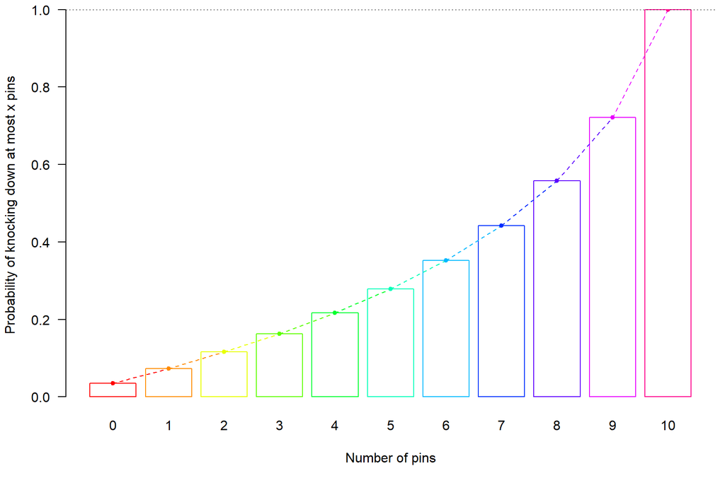

# Cumulative Density Functions (CDFs)

- Now $\Omega$ is an interval; e.g. $\Omega=\mathbb{R}$, $\Omega=\mathbb{R}_{+}$, $\Omega=\left(a,b\right)$, $\Omega=\left(0,1\right]$, etc.
- $\Omega$ has an infinite number of points with zero width, so $\Pr\left(X = x\right) \downarrow 0$
- $\Pr\left(X\leq x\right)$ is called the Cumulative Density Function (CDF) from $\Omega$ to $\left[0,1\right]$
- No conceptual difference between a CMF and a CDF except emphasis on whether $\Omega$ is discrete or continuous so we use $F\left(x \mid \boldsymbol{\theta}\right)$ for both

# From CDF to a Probability Density Function (PDF)

- $\Pr\left(a<X\leq x\right)=F\left(x \mid \boldsymbol{\theta}\right)-F\left(a \mid \boldsymbol{\theta}\right)$ as in the discrete case
- If $x=a+h$, $\frac{F\left(x \mid \boldsymbol{\theta}\right)-F\left(a \mid \boldsymbol{\theta}\right)}{x-a}=\frac{F\left(a+h \mid \boldsymbol{\theta}\right)-F\left(a \mid \boldsymbol{\theta}\right)}{h}$ is the slope of a line segment
- If we then let $h\downarrow0$, $\frac{F\left(a+h \mid \boldsymbol{\theta}\right)-F\left(a \mid \boldsymbol{\theta}\right)}{h}\rightarrow\frac{\partial F\left(a \mid \boldsymbol{\theta}\right)}{\partial a}\equiv f\left(x \mid \boldsymbol{\theta}\right)$ is still the RATE OF CHANGE in $F\left(x \mid \boldsymbol{\theta}\right)$ at $x$, i.e. the slope of the CDF at $x$
- The derivative of $F\left(x\right)$ with respect to $x$ is the Probability Density Function (PDF) & denoted $f\left(x\right)$, which is always positive because the CDF increases
- $f\left(x\right)$ is NOT a probability (it is a probability’s slope) but is used like a PMF!!!!!!!!!
- Conversely, $F\left(x\mid\theta\right) = \int_{-\infty}^x f\left(x \mid \theta\right)dx$ is the area under the PDF up to $x$
- Can use WolframAlpha to take [derivatives](https://www.wolframalpha.com/input/?i=partial+derivative) or do (some) [definite integrals](https://www.wolframalpha.com/input/?i=definite+integral) but Columbia students can and should [download](https://cuit.columbia.edu/content/mathematica) the full Mathematica for free. Also, you can do symbolic stuff in Python, whether [locally](https://www.sympy.org/en/index.html) or [online](https://www.sympygamma.com/).

# Correspondence between Discrete & Continuous

[output not shown]

# Uniform Distribution

- Standard uniform distribution for $X \in \Omega = \left[0,1\right]$ with CDF $F\left(x\right) = x$ and PDF $f\left(x\right) = 1$, so the PDF is just a horizontal line at $1$
- Can randomly draw from a standard uniform with [hardware](https://en.wikipedia.org/wiki/RDRAND) but `runif` uses pseudo-random software emulation (conditional on `set.seed`) for speed
- If $\Omega = \left[a,b\right]$, CDF is $F\left(x \mid a,b\right) = \frac{x - a}{b - a}$, PDF is $f\left(x \mid, a,b\right) = \frac{1}{b - a}$, and draw is `a + (b - a) * runif(n = 1)` or `runif(n = 1, min = a, max = b)`
- Let $g\left(X\right) = -\ln f\left(x \mid a,b\right)$. The (differential) entropy of $X$ is defined as
  $$\mathbb{E}g\left(X\right) = \int_a^b g\left(x\right) f\left(x \mid a, b\right) =
  -\int_a^b \ln f\left(x \mid a,b\right) f\left(x \mid a,b\right) dx$$
  and is maximized for continuous RVs on $\Omega = \left[a,b\right]$ by $f\left(x \mid a,b\right) = \frac{1}{b - a}$. So, uniform distribution conveys no information about $X$ beyond that $\Omega = \left[a,b\right]$.- no ADDITIONAL info - not COMPLETELY uninformative - just no more than what we started with

# Exponential Distribution

- Can draw from the standard exponential distribution for $X \in \Omega = \mathbb{R}_+$ by passing a standard uniform deviate, $p$, through $F^{-1}\left(p\right) = -\ln\left(1 - p\right) = x$
- $F^{-1}\left(p\right)$ is called a quantile function from $\left[0,1\right]$ to $\Omega$, which can be inverted to obtain the CDF. In this case, $F\left(x\right) = 1 - e^{-x} = p$ and thus $f\left(x\right) = e^{-x}$.
- To draw from a general exponential distribution with expectation $\mu > 0$, do `mu * qexp(runif(n = 1))` or `rexp(n = 1, rate = 1 / mu)`. In general, $F^{-1}\left(p \mid \mu\right) = -\mu \ln \left(1 - p\right)$, $F\left(x \mid \mu\right) = 1 - e^{-\frac{x}{\mu}}$, $f\left(x \mid \mu\right) = \frac{1}{\mu}e^{-\frac{x}{\mu}}$,
  $$\mu = \mathbb{E}X = \int_0^\infty x \frac{1}{\mu} e^{-\frac{x}{\mu}} dx =
  \left.-\left(x + \mu\right)e^{-\frac{x}{\mu}}\right|_0^\infty \rightarrow
  0 + \mu$$
- Let $g\left(X\right) = -\ln f\left(x \mid \mu\right)$. The (differential) entropy of $X$ is defined as $\mathbb{E}g\left(X \mid \mu\right)$ and is maximized for continuous RVs on $\Omega = \mathbb{R}_+$ with $\mathbb{E}X = \mu$ when $f\left(x \mid \mu\right) = \frac{1}{\mu}e^{-\frac{x}{\mu}}$ is the exponential PDF.

# Plots for the Standard Exponential Distribution

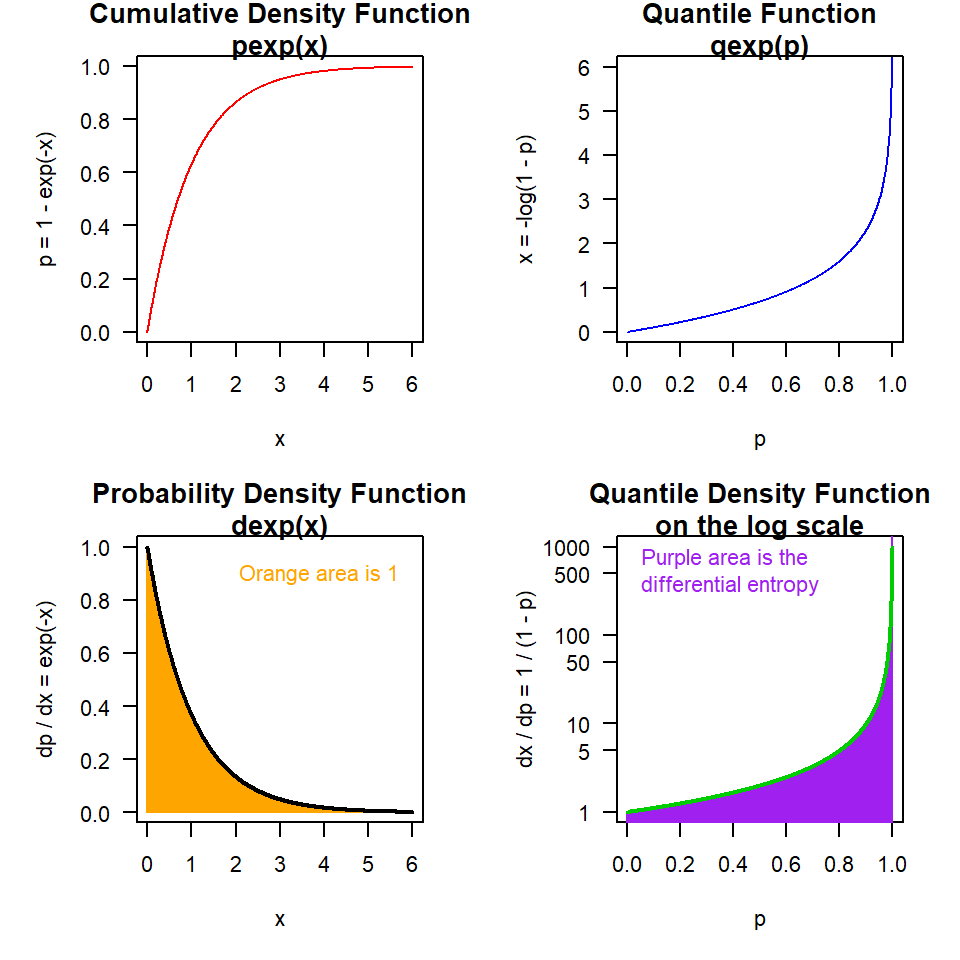

- Functional forms are specific to the standard exponential distribution but relationships among concepts are general to all continuous RVs
- Start with the top right plot. A simple algorithm to randomly draw from $\Omega$ a realization of $x$ is to draw $p$ from a standard uniform, go up to the blue curve, and left to the vertical axis.
- Flip the axes to go from blue to red
- Red curve has a slope at every point and its slope is the black curve
- Substitute $F^{-1}\left(p\right)$ for $x$ in black and take the reciprocal to get green

# Standard Normal Distribution

- Let $\phi\left(x\right) = \frac{e^{-\frac{1}{2}x^2}}{\sqrt{2\pi}}$ and $\Phi\left(x\right) = \frac{1}{2} + \phi\left(x\right) \sum_{n = 0}^\infty \frac{x^{2n + 1}}{\left(2n + 1\right)!!}$, which involves the odd [double factorial](https://en.wikipedia.org/wiki/Double_factorial) function, and $F^{-1}\left(p\right) = x: \Phi\left(x\right) = p$ is implicit
- The CDF for the standard normal distribution on $\Omega = \mathbb{R}$ is $F\left(x\right) = \Phi\left(x\right)$ and the PDF is $f\left(x\right) = \phi\left(x\right) = \frac{\partial}{\partial x} \Phi\left(x\right)$, which can be shown fairly easily
- Can draw from the standard normal distribution by passing a standard uniform variate, $p$, through $F^{-1}\left(p\right)$, which is implemented as `qnorm` in R

```r
c(set.seed(20220214), direct = rnorm(1), set.seed(20220214), composed = qnorm(runif(1)))
```

```
##    direct  composed
## 0.8441673 0.8441674
```

- Since $\phi\left(x\right)$ is an even function that only depends on $x$ through $x^2$, you can show that $\mathbb{E}X = \int_{-\infty}^\infty x \phi\left(x\right) dx = \int_{-\infty}^0 x f\left(x\right) + \int_{0}^\infty x \phi\left(x\right) = 0$

# General (univariate) Normal Distribution

- If $Z$ is distributed standard normal, $X = Z \sigma + \mu$ is distributed normal with expectation $\mu$ and standard deviation $\sigma > 0$
- Can draw from a normal distribution via `rnorm(n = 1, mu, sigma)` or, equivalently, `qnorm(runif(n = 1)) * sigma + mu`
- Let $g\left(X\right) = -\ln f\left(x \mid \mu, \sigma\right)$. The (differential) entropy of $X$ is defined as $\mathbb{E}g\left(X \mid \mu, \sigma\right)$ and is maximized for continuous RVs on $\Omega = \mathbb{R}$ with $\mathbb{E}X = \mu$ and $\mathbb{E}\left(X - \mu\right)^2 = \sigma^2$ when $f\left(x \mid \mu, \sigma\right) = \frac{e^{-\frac{1}{2} \left(\frac{x - \mu}{\sigma}\right)^2}}{\sigma \sqrt{2 \pi}}$ is the normal PDF.
- It may seem as if the normal distribution is very informative, but it conveys the least information beyond the fact that it is a real number with expectation $\mu$ and standard deviation $\sigma$. Thus, it is easy to move when conditioning on data.

# Different Parameterizations of a Distribution

- The normal PDF can be written in terms of an expectation, $\mu$, and a STANDARD DEVIATION, $\sigma$: $f\left(x \mid \mu, \sigma\right) = \frac{e^{-\frac{1}{2}\left(\frac{x - \mu}{\sigma}\right)^2}}{\sigma\sqrt{2\pi}}$
- The normal PDF can be written in terms of an expectation, $\mu$, and a VARIANCE, $\nu = \sigma^2$: $f\left(x \mid \mu, \nu\right) = \frac{e^{-\frac{1}{2\nu}\left(x - \mu\right)^2}}{\sqrt{2\pi\nu}}$
- The normal PDF can be written in terms of an expectation, $\mu$, and a PRECISION, $\tau = \frac{1}{\nu}$: $f\left(x \mid \mu, \tau\right) = \frac{\sqrt{\tau} e^{-\frac{\tau}{2}\left(x - \mu\right)^2}}{\sqrt{2\pi}}$
- All three parameterizations imply the same things about $X$. Using $\sigma$ makes the most sense empirically because it is in the same units as $X$. Using $\nu$ is often convenient for proofs. Using $\tau$ facilitated Bayesian computations before Stan was released in $2011$ and is used in the Lancaster reading for next week.

# Bivariate Normal Distribution

If $\Pr\left(X \leq x \bigcap Y \leq y \mid \boldsymbol{\theta}\right) = F\left(x,y\mid\boldsymbol{\theta}\right)$ is a biviariate CDF, then the bivariate PDF is $\frac{\partial^2}{\partial x \partial y}F\left(x,y\mid\boldsymbol{\theta}\right)$. This also generalizes beyond two dimensions. The PDF of the bivariate normal distribution over $\Omega = \mathbb{R}^2$ has five parameters:
$$f\left(x,y\mid \mu_X,\mu_Y,\sigma_X,\sigma_Y,\rho\right) =\\
\frac{1}{2\pi\sigma_X\sigma_Y\sqrt{1-\rho^2}}e^{-\frac{1}{2\left(1-\rho^2\right)}
\left(\left(\frac{x - \mu_X}{\sigma_X}\right)^2 +
\left(\frac{y - \mu_Y}{\sigma_Y}\right)^2 -
2\rho\frac{x - \mu_X}{\sigma_X}\frac{y - \mu_Y}{\sigma_Y}\right)} = \\
\frac{1}{\sigma_X\sqrt{2\pi}}e^{-\frac{1}{2}\left(\frac{x - \mu_X}{\sigma_X}\right)^2} \times
\frac{1}{\color{blue}{\sigma_Y\sqrt{1-\rho^2}}\sqrt{2\pi}}e^{-\frac{1}{2}
\left(\frac{y - \left(\color{red}{\mu_Y + \frac{\sigma_Y}{\sigma_X}\rho\left(x-\mu_x\right)}\right)}
{\color{blue}{\sigma_Y\sqrt{1-\rho^2}}}\right)^2},$$
where the first term is a marginal normal PDF and the second is a conditional normal PDF w/ parameters $\color{red}{\mu = \mu_Y + \frac{\sigma_Y}{\sigma_X}\rho\left(x-\mu_X\right)}$ & $\color{blue}{\sigma = \sigma_Y\sqrt{1-\rho^2}}$.

# Bivariate Normal PDF Visualized

```r
dbinorm <- function(x, y,
                    mean_x = 5,
                    mean_y = 5,
                    sd_x = 1.5,
                    sd_y = 1.0,
                    rho = 0.5) {
  beta <- rho * sd_y / sd_x
  mu_yx <- mean_y + beta * (x - mean_x)
  sigma_yx <- sd_y * sqrt(1 - rho ^ 2)
  return( dnorm(x, mean_x, sd_x) *
          dnorm(y, mu_yx, sigma_yx) )
} # does not come with R so define it
library(rgl)
persp3d(dbinorm, xlim = c(0, 10),
        ylim = c(0, 10), axes = FALSE,
        alpha = 0.75, col = rainbow,
        zlab = "density")
rglwidget()
```

[interactive chart not shown]

# Bayes Rule with Normal Distributions

- Suppose $X$ and $Y$ are distributed bivariate normal with parameters $\mu_X,\mu_Y,\sigma_X,\sigma_Y$ and $\rho$. Thus,
  $$f\left(x \mid y, \mu_X,\mu_Y,\sigma_X,\sigma_Y, \rho \right) =
  \frac{f_X\left(x \mid \mu_X, \sigma_X\right)
  f_{Y\mid X}\left(y \mid \color{red}{\mu_Y + \frac{\sigma_Y}{\sigma_X}\rho\left(x-\mu_X\right)},
  \color{blue}{\sigma_Y\sqrt{1 - \rho^2}}\right)}
  {f\left(\bcancel{x}, y \mid\mu_X,\mu_Y,\sigma_X,\sigma_Y,\rho\right)}$$
  and the marginal PDF of $Y$ is univariate normal (by interchanging $X$ w/ $Y$ on the previous slides) since
  $$f\left(\bcancel{x}, y \mid\mu_X,\mu_Y,\sigma_X,\sigma_Y,\rho\right) =
  \int_{-\infty}^\infty f\left(x, y \mid\mu_X,\mu_Y,\sigma_X,\sigma_Y,\rho\right) dx =
  \frac{e^{-\frac{1}{2}\left(\frac{y - \mu_Y}{\sigma_Y}\right)^2}}{\sigma_Y \sqrt{2 \pi}} =
  f_Y\left(y \mid \mu_Y, \sigma_Y\right)$$
- In this very rare case, marginalization can be done analytically, but the area can also be obtained via:

```r
mu_X <- 9.8; sigma_X <- 7.6; mu_Y <- 5.4; sigma_Y <- 3.2; rho <- -0.1; y <- sqrt(5)
denominator <- integrate(dbinorm, lower = -Inf, upper = Inf, y = y, # uses little trapezoids basically
                         mean_x = mu_X, mean_y = mu_Y, sd_x = sigma_X, sd_y = sigma_Y, rho = rho)$value
```

```r
format(c(exact = dnorm(y, mean = mu_Y, sd = sigma_Y), numeric = denominator), digits = 10)
```

```
##           exact         numeric
## "0.07646809985" "0.07646809983"
```

# Biontech / Pfizer [Analysis](http://skranz.github.io//r/2020/11/11/CovidVaccineBayesian.html) of First Covid Vaccine

- Let $\pi_v$ be the probability of getting covid given that someone is vaccinated (in the Fall of 2020), $\pi_c$ be the probability of getting covid given that someone is not vaccinated, $\theta = \frac{\pi_v}{\pi_v + \pi_c}$, and the “Vaccine Effect” is $\mbox{VE}\left(\theta\right) = \frac{1 - 2\theta}{1 - \theta} \leq 1$
- Beta distribution has PDF $f\left(\theta \mid a,b\right) = \frac{\theta^{a - 1}\left(1 - \theta\right)^{b - 1}} {\int_0^1 t^{a - 1}\left(1 - t\right)^{b - 1}dt} = \frac{\theta^{a - 1}\left(1 - \theta\right)^{b - 1}}{B\left(a,b\right)}$
- Prior for $\theta$ was Beta with $a = 0.700102$ and $b = 1$, which was chosen (poorly) so that the VE at $\mathbb{E}\theta = \frac{a}{a + b}$ was about $0.3$ (but it mattered little)

```r
library(dplyr)
library(ggplot2)
a <- 0.700102
b <- 1
ggplot(tibble(theta = rbeta(n = 10^6, shape1 = a, shape2 = b),
              VE = (1 - 2 * theta) / (1 - theta))) +
  geom_density(aes(x = VE)) + xlim(-5, 1) # see next slide
```

# Implied Prior Distribution of $\mbox{VE}\left(\theta\right)$

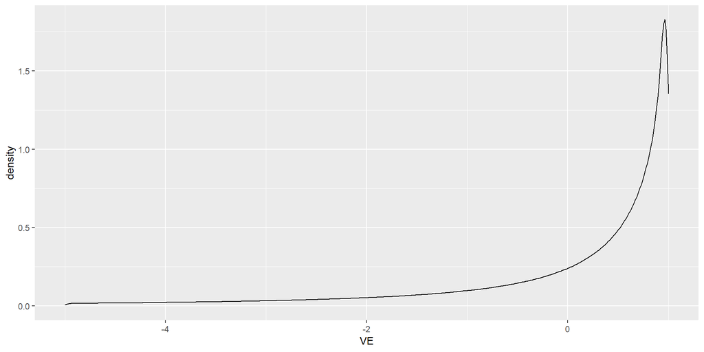

# Deriving a Posterior Distribution of $\theta$ Analytically

- $\Pr\left(y \mid \theta, n\right) = {n \choose y} \theta^y \left(1 - \theta\right)^{n - y}$ is binomial given $\theta$, where “success” is getting covid when vaccinated and “failure” is getting covid when unvaccinated
- $y = 8$ vaccinated people and $n - y = 86$ non-vaccinated people got covid
- What are their beliefs about $\theta$? ($\propto$ means “proportional to”, i.e. the kernel)
  $$f\left(\theta \mid a,b,n,y\right) = \frac{f\left(\theta \mid a,b\right) L\left(\theta;n,y\right)}
  {\int_0^1 f\left(\theta \mid a,b\right) L\left(\theta;n,y\right) d\theta} \propto \\
  \theta^{a - 1} \left(1 - \theta\right)^{b - 1} \theta^{y}\left(1-\theta\right)^{n-y}
  = \theta^{a + y - 1} \left(1 - \theta\right)^{b + n - y - 1} = \theta^{a^\ast - 1} \left(1 - \theta\right)^{b^\ast - 1}$$
  where $a^{\ast}=a+y = 8.700102$ and $b^{\ast}=b+n-y = 87$
- $f\left(\theta \mid a^\ast,b^\ast\right)$ has the kernel of a Beta PDF and therefore its normalizing constant must be the reciprocal of $B\left(a^\ast,b^\ast\right) = \int_0^1 t^{a^\ast - 1} \left(1 - t\right)^{b^\ast - 1} dt$

# Implied Posterior Distribution of $\mbox{VE}\left(\theta\right)$

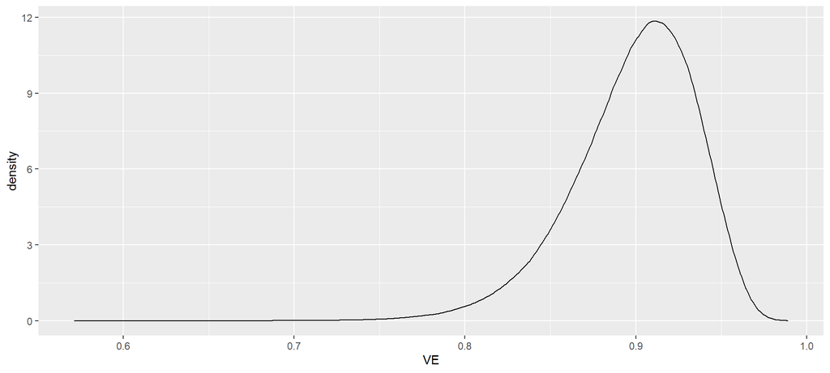

```r
y <- 8; n <- 94; a_star <- a + y; b_star <- b + n - y
ggplot(tibble(theta = rbeta(n = 10^6, shape1 = a_star, shape2 = b_star),
              VE = (1 - 2 * theta) / (1 - theta))) + geom_density(aes(x = VE))
```

# Bowling with a Continuous Inability Parameter

- Last week, we used $\Pr\left(x \mid n, \Upsilon\right) = \frac{\log_{n + 2 + \Upsilon}\left(1 + \frac{1}{n + 1 + \Upsilon - x}\right)}{1 - \log_{n + 2 + \Upsilon}\left(1 + \Upsilon\right)}$ but this does not actually require that $\Upsilon$ be a non-negative integer
- Substitute $1 + \Upsilon = \theta$ where $\theta \geq 0$ is continuous
- We can work backward from $\mathbb{E}X_1 \mid \theta$ to a prior for $\theta$

```r
library(scales)
E <- function(theta) sapply(theta, FUN = function(t) sum(Omega * Pr(Omega, n = 10, t)))
ggplot() + # Pr(x, n = 10, theta = 1) and Omega were defined above by source("bowling.R")
  geom_function(fun = ~E(.x)) + # see next slide
  scale_x_continuous(limits = c(1e-16, 11000), trans  = "log10",
                     breaks = trans_breaks("log10", function(x) 10^x),
                     labels = trans_format("log10", math_format(10^.x))) +
  ylab("Conditional expectation of first roll given theta") +
  xlab("theta (log scale)")
```

# Plot from Previous Slide

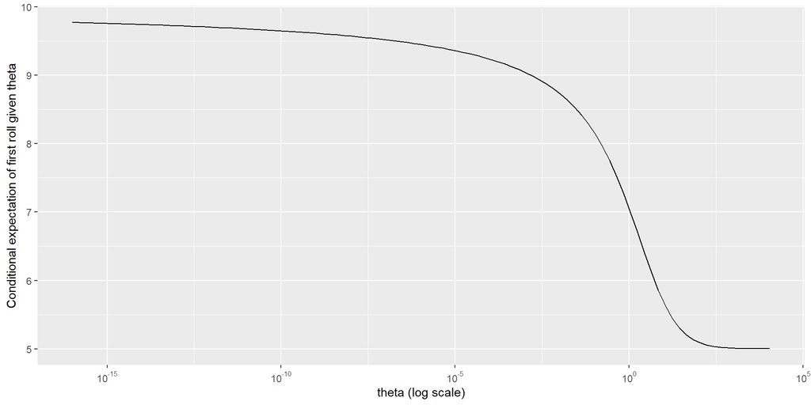

# Marginal Probability of the First Roll in Bowling

- Suppose we utilize a standard exponential prior for $\theta$, which has the MARGINAL PDF $f\left(\theta\right) = e^{-\theta}$ and expectation $\mu = 1$
- The CONDITIONAL PMF of $X_1 \mid \theta$ is $\Pr\left(x_1 \mid n, \theta\right) = \frac{\log_{n + 1 + \theta}\left(1 + \frac{1} {n + \theta - x_1}\right)}{1 - \log_{n + 1 + \theta}\left(\theta\right)}$
- The BIVARIATE PDF of $\theta$ and $X_1$ is $f\left(\theta, x_1 \mid n\right) = e^{-\theta} \frac{\log_{n + 1 + \theta}\left(1 + \frac{1}{n + \theta - x_1}\right)}{1 - \log_{n + 1 + \theta}\left(\theta\right)}$
- The MARGINAL PMF of $X_1$ is
  $$\Pr\left(x_1 \mid n\right) = f\left(\bcancel{\theta}, x_1 \mid n\right) =
  \int_0^\infty e^{-\theta} \frac{\log_{n + 1 + \theta}\left(1 + \frac{1}{n + \theta - x_1}\right)}
  {1 - \log_{n + 1 + \theta}\left(\theta\right)}d\theta$$
  but we can’t obtain the antiderivative to evalute the area
- The [Risch algorithm](https://en.wikipedia.org/wiki/Risch_algorithm) can tell you if a function has an elementary antiderivative

# Marginalized Probability of the First Roll

```r
joint <- function(theta, x_1) dexp(theta) * sapply(theta, FUN = Pr, x = x_1, n = 10)
```

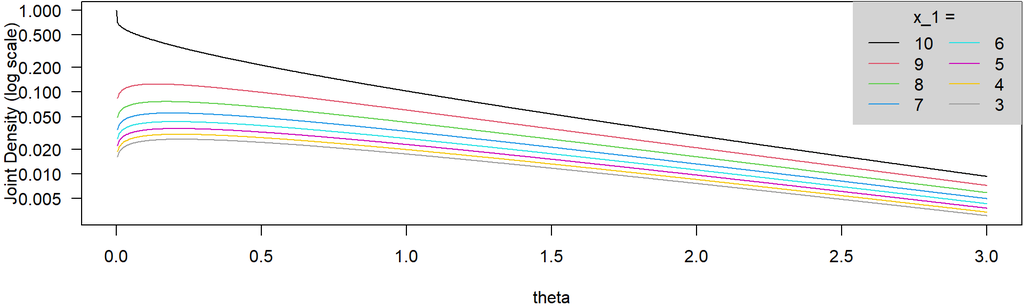

```r
marginal <- integrate(joint, lower = 0, upper = Inf, x_1 = 8)$value
marginal
```

```
## [1] 0.1059296
```

# Deterministic Posterior PDF Given $x_1 = 8$

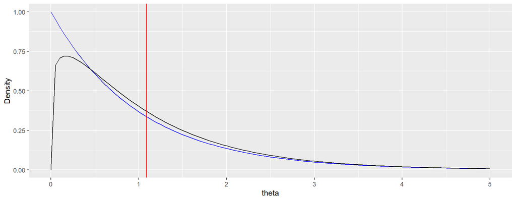

```r
E <- integrate(function(t) t * joint(t, x = 8) / marginal, lower = 0, upper = Inf)$value
ggplot() + xlim(0, 5) + xlab("theta") + ylab("Density") +
  geom_function(fun = ~dexp(.x), color = "blue") + # prior PDF
  geom_function(fun = ~joint(.x, x = 8) / marginal, color = "black") + # posterior PDF
  geom_vline(aes(xintercept = E), color = "red") # posterior expectation
```

# Simulated Posterior Distribution Given $x_1 = 8$

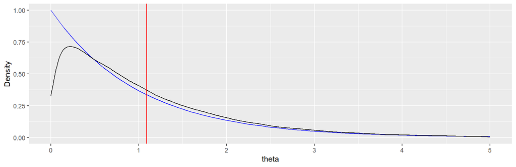

```r
tibble(theta = rexp(n = 10^6)) %>% # "infinite" draws from standard exponential prior
  filter(8 == vapply(theta, FUN.VALUE = integer(1), FUN = function(t)
    sample(Omega, size = 1, prob = Pr(Omega, n = 10, t)))) %>%
  ggplot() + xlim(0, 5) + xlab("theta") + ylab("Density") +
  geom_function(fun = ~dexp(.x), color = "blue") + # prior PDF (exact)
  geom_density(aes(x = theta), color = "black")  + # posterior PDF (approximate)
  geom_vline(aes(xintercept = mean(theta)), color = "red") # posterior mean (approximate)
```